# Descriptive Analysis of Bank Loan Data

Cheng Peng

# 1 Introduction

In this brief report, we will summarize the working data set collected from banks that received loan applications from small businesses with a partial warranty from the Small Business Association (SBA). The data is in a public domain and can be found at https://pengdsci.github.io/datasets/#sba-loan. We use the free open-source R (http://www.r-project.com) to perform descriptive analysis.

```r
loan01 = read.csv("https://pengdsci.github.io/datasets/SBAloan/w06-SBAnational01.csv", header = TRUE)[, -1]
loan02 = read.csv("https://pengdsci.github.io/datasets/SBAloan/w06-SBAnational02.csv", header = TRUE)[, -1]
loan03 = read.csv("https://pengdsci.github.io/datasets/SBAloan/w06-SBAnational03.csv", header = TRUE)[, -1]
loan04 = read.csv("https://pengdsci.github.io/datasets/SBAloan/w06-SBAnational04.csv", header = TRUE)[, -1]
loan05 = read.csv("https://pengdsci.github.io/datasets/SBAloan/w06-SBAnational05.csv", header = TRUE)[, -1]
loan06 = read.csv("https://pengdsci.github.io/datasets/SBAloan/w06-SBAnational06.csv", header = TRUE)[, -1]
loan07 = read.csv("https://pengdsci.github.io/datasets/SBAloan/w06-SBAnational07.csv", header = TRUE)[, -1]
loan08 = read.csv("https://pengdsci.github.io/datasets/SBAloan/w06-SBAnational08.csv", header = TRUE)[, -1]
loan09 = read.csv("https://pengdsci.github.io/datasets/SBAloan/w06-SBAnational09.csv", header = TRUE)[, -1]
loan = rbind(loan01, loan02, loan03, loan04, loan05, loan06, loan07, loan08, loan09)
# dim(bankLoan)
#names(bankLoan)
```

```r
var.names = names(loan)
my.var = var.names[c(1,6,21,26)]
my.new.data = loan[1:15, my.var]
dim(my.new.data)
```

```
[1] 15  4
```

Based on the information given in the data set description, we can create a basic RMD table.

[output not shown]

One nice feature of this method is that you have parameters you can control to make a better good looking graphic. For more information on embedding images in RMD, please visit https://yihui.org/knitr/options/.

In the next sections, we will perform frequency analysis for character variables and descriptive numeric measures for numerical variables.

# 2 Variable Inspection

I use an informal term *variable inspection* in this note to have a glance at the distribution of the individual variables of interest to be used in the analysis. We only want to use this data for sampling purposes for now. A categorical variable is needed to do stratified sampling.

## 2.1 Frequency Analysis for Category Variables

Some of the categories may have only a small number of loans, we should combine small sub-populations in a **meaningful** way so that we can use the “balanced” variable for stratification.

For example, we can look at the variable NAICS. Since R is case sensitive, before you write code to select a variable for analysis, you may want to see the exact form of the variable name in your data set to avoid unnecessary frustration.

```r
name.vec=names(loan)                          # this is a character vector
name.mtx = matrix(name.vec, ncol=3)           # define a matrix and then make a table
colnames(name.mtx)=c("variable name", "variable name", "variable name" ) # assign column names: This is required!
kable(name.mtx)                               # make a nice looking table: kable() isa fun function in knitr()
```

| variable name | variable name | variable name |
| --- | --- | --- |
| LoanNr_ChkDgt | ApprovalFY | LowDoc |
| Name | Term | ChgOffDate |
| City | NoEmp | DisbursementDate |
| State | NewExist | DisbursementGross |
| Zip | CreateJob | BalanceGross |
| Bank | RetainedJob | MIS_Status |
| BankState | FranchiseCode | ChgOffPrinGr |
| NAICS | UrbanRural | GrAppv |
| ApprovalDate | RevLineCr | SBA_Appv |

Next, I use the North America Industry Classification System (NAICS) as an example to demonstrate how to obtain a frequency table from R and what information you need to know in designing a stratified sampling. The following code chunk produces a frequency distribution (table).

```r
naics =as.character(loan$NAICS)  # make a character vector
N=length(naics)                  # find the size of the data.
f.table = -sort(-table(naics))   # sort the vector in descending order
n = length(f.table)              # find the number of distinct industries
n.0 = sum(f.table < 900)         # industry with less than 0.1% of the population size
# A note of length of R variable: the latest version of R has upped
# the maximum length of variable names from 256 characters to a whopping 10,000.
# We should try our best to give meaningful names to R variables.
kable(cbind(Population.size = N, Number.of.Industries=n, Sub.Pop.less.1000 = n.0))
```

| Population.size | Number.of.Industries | Sub.Pop.less.1000 |
| --- | --- | --- |
| 899164 | 1312 | 1140 |

In the above frequency distribution table, we observe the following

- About $87\%$ of NAICS classified industries have less than 900 applications. If the sample size is not large enough, $87\%$ of the industries in the population will be unlikely represented in an SRS sample.
- It makes sense to combine these small sub-populations with a larger similar population.
- It also makes sense to define a study population by including a set of sub-populations with a certain size.

## 2.2 Summary of Numerical Variables

In general, descriptive analyses of the numerical variable mainly focus on the distribution of the variable. For example, for a multi-modal or an extremely skewed variable, we may want to discretize it and to make a discrete variable for analysis.

We can also discretize a numerical variable based on the distribution to make a stratification variable.

# 3 Initial Data Management

We will do some basic data management to create a data set that will be used as a study population. We can add a variable to the data set and used a sampling list. Some R functions are convenient to use for setting data based on observations (not variable!).

## 3.1 Add New Variable to a Dataframe

Here is an example. I would add an ID variable to the existing data frame so that you can use it as the sampling frame in the SRS sampling scheme.

```r
pop.N = length(loan$LoanNr_ChkDgt)        # population size
loan$obs.ID = 1:pop.N                     # adding an observation ID to the dataframe
# Next, we choose first 10 row of a subset of variables to make a table for inspection.
kable(as.matrix(loan[1:10, c("obs.ID", "LoanNr_ChkDgt", "Name", "City", "State", "Bank")]))
```

| obs.ID | LoanNr_ChkDgt | Name | City | State | Bank |
| --- | --- | --- | --- | --- | --- |
| 1 | 1000014003 | ABC HOBBYCRAFT | EVANSVILLE | IN | FIFTH THIRD BANK |
| 2 | 1000024006 | LANDMARK BAR & GRILLE (THE) | NEW PARIS | IN | 1ST SOURCE BANK |
| 3 | 1000034009 | WHITLOCK DDS, TODD M. | BLOOMINGTON | IN | GRANT COUNTY STATE BANK |
| 4 | 1000044001 | BIG BUCKS PAWN & JEWELRY, LLC | BROKEN ARROW | OK | 1ST NATL BK & TR CO OF BROKEN |
| 5 | 1000054004 | ANASTASIA CONFECTIONS, INC. | ORLANDO | FL | FLORIDA BUS. DEVEL CORP |
| 6 | 1000084002 | B&T SCREW MACHINE COMPANY, INC | PLAINVILLE | CT | TD BANK, NATIONAL ASSOCIATION |
| 7 | 1000093009 | MIDDLE ATLANTIC SPORTS CO INC | UNION | NJ | WELLS FARGO BANK NATL ASSOC |
| 8 | 1000094005 | WEAVER PRODUCTS | SUMMERFIELD | FL | REGIONS BANK |
| 9 | 1000104006 | TURTLE BEACH INN | PORT SAINT JOE | FL | CENTENNIAL BANK |
| 10 | 1000124001 | INTEXT BUILDING SYS LLC | GLASTONBURY | CT | WEBSTER BANK NATL ASSOC |

## 3.2 Accessing Observations Meeting Certain Conditions

Setting a data set based on variables is straightforward. you need the following command to define a subset with only the listed 6 variables.

```
loan[ , c("obs.ID", "LoanNr_ChkDgt", "Name", "City", "State", "Bank")]
```

If we define a subset with conditions in one or more variables, we can use a powerful function $which()$. The following example defines a subset

```r
subset.id = which(loan$Bank=="FIFTH THIRD BANK" | loan$Bank=="CENTENNIAL BANK") # "|" means "or".
centennial.5th3rd = loan[subset.id, ]
sizes = dim(centennial.5th3rd)
mtx=cbind(obs.n = sizes[1], var.n = sizes[2])
kable(mtx)
```

| obs.n | var.n |
| --- | --- |
| 5628 | 28 |

## 3.3 Random Sampling

As you have already seen that SRS is the foundation of probabilistic sampling plans. There are two types of SRS: SRS with and without replacement. The built-in R function $sample()$ can do both with and without replacement plans. It can also do weighted sampling.

```
sample(x, size, replace = FALSE, prob = NULL)
# x = vector
# size = sample size
# replace = FALSE, without replacement
# replace = TRUE, with replacement
# prob =  a vector of probabilities (weights)
          of corresponding observations
          to do weighted sampling.
```

# 4 Some Useful Tips

## 4.1 Embed External Images Into RMD

For example, you can make an image of the variable list and embed it into this document. To do this, create an image and save it in a folder where you save this R markdown document. You then can use the following R code chunk to embed the image into a file in the format of html, word, or pdf when you knit this RMD document.

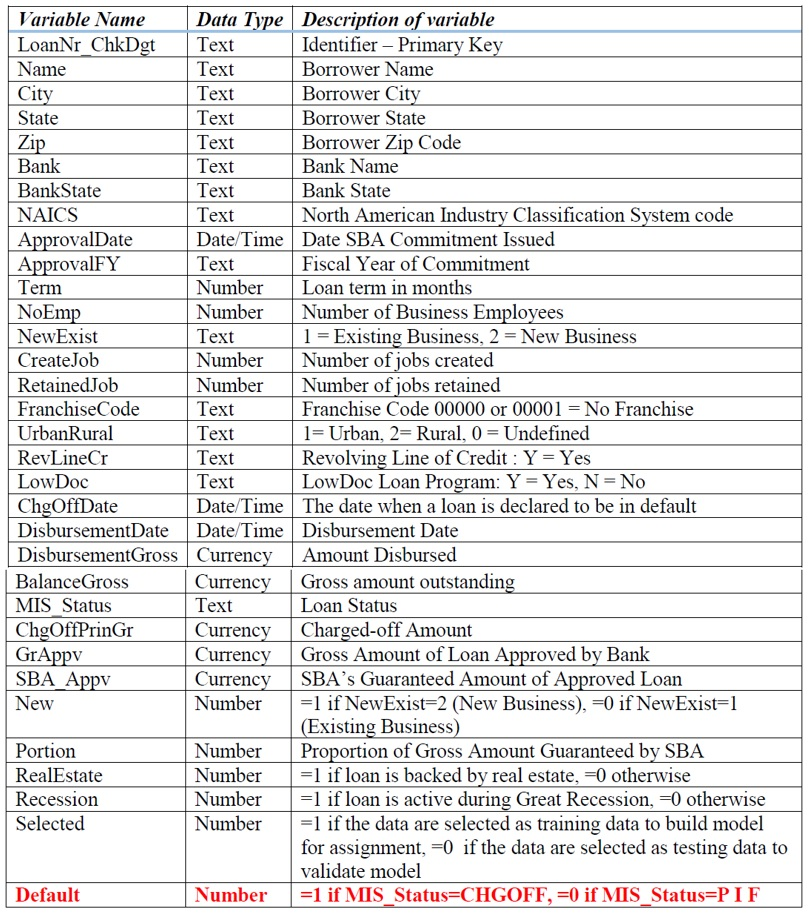

List of all variables and the description of each variable